# Store block information

Satya Golla and Steve Simon

Created 2022-03-12

This program will read in census shapefiles for census blocks, convert them into the simple features (sf) format, and store the results for later use.

### General information

The starting point for downloading most Census shapefiles is [here](https://www.census.gov/geographies/mapping-files/time-series/geo/tiger-line-file.html). The ftp site is a bit more difficult to navigate, but leads you directly to the files that you want.

It helps to know the FIPS (Federal Information Processing System) codes for Kansas (20) and Missouri (29).

Files with a postfix of “20” either in the filename or among some of the variable names indicates that the data or shapefile is from the 2020 Census. A postfix of “10” indicates that the data or shapefile is from the 2010 Census.

The important counties for this program are

Cass County, MO (29037) Clay County, MO (29047) Jackson County, MO (29095) Johnson County, KS (20091) Leavenworth County, KS (20103) Platte County, MO (29165) Wyandotte County, KS (20209)

Some of the variables in the shape files are rather cryptic. An explanation of MTFCC20 appears [here](https://www2.census.gov/geo/pdfs/maps-data/data/tiger/tgrshp2009/TGRSHP09AF.pdf).

### US census blocks

A census block is the smallest geographical unit used by the United States Census Bureau for tabulation of 100-percent data. There are files for census blocks for individual counties in each state.

Use the st_read function from the [sf package](https://r-spatial.github.io/sf/) to read in the data. You may need to convert the coordinate reference system. That uses the st_crs function, also of the sf package. Census blocks are uniquely identified by a two digit state FIPS code, a three digit county FIPS code, a six digit tract code, and a four digit block code. These are combined into a fifteen digit code, GEOID.

### Read block shapefiles for each county

```r
library(sf)
library(tidyverse)
path_name <- "../data"
```

### Johnson County, KS (20091)

```r
file_name <- "bl/tl_2020_20091_tabblock20.shp"
path_name                              %>%
  paste(file_name, sep="/")            %>%
  st_read(stringsAsFactors=FALSE)       -> s20091
glimpse(s20091)
```

```
## Rows: 8,235
## Columns: 16
## $ STATEFP20  <chr> "20", "20", "20", "20", "20", "20", "20", "20", "20", "20",~
## $ COUNTYFP20 <chr> "091", "091", "091", "091", "091", "091", "091", "091", "09~
## $ TRACTCE20  <chr> "051801", "051400", "051500", "980003", "980003", "052505",~
## $ BLOCKCE20  <chr> "2010", "3006", "2005", "1009", "1005", "2007", "1000", "20~
## $ GEOID20    <chr> "200910518012010", "200910514003006", "200910515002005", "2~
## $ NAME20     <chr> "Block 2010", "Block 3006", "Block 2005", "Block 1009", "Bl~
## $ MTFCC20    <chr> "G5040", "G5040", "G5040", "G5040", "G5040", "G5040", "G504~
## $ UR20       <chr> NA, NA, NA, NA, NA, NA, NA, NA, NA, NA, NA, NA, NA, NA, NA,~
## $ UACE20     <chr> NA, NA, NA, NA, NA, NA, NA, NA, NA, NA, NA, NA, NA, NA, NA,~
## $ UATYPE20   <chr> NA, NA, NA, NA, NA, NA, NA, NA, NA, NA, NA, NA, NA, NA, NA,~
## $ FUNCSTAT20 <chr> "S", "S", "S", "S", "S", "S", "S", "S", "S", "S", "S", "S",~
## $ ALAND20    <dbl> 38533, 51754, 104623, 0, 95934, 199509, 30765, 354042, 7350~
## $ AWATER20   <dbl> 0, 0, 0, 73995, 0, 0, 0, 1582, 0, 0, 0, 0, 111, 0, 19008, 1~
## $ INTPTLAT20 <chr> "+38.9760924", "+38.9791667", "+38.9778033", "+38.9859944",~
## $ INTPTLON20 <chr> "-094.6412527", "-094.6370261", "-094.6291535", "-094.80067~
## $ geometry   <POLYGON [°]> POLYGON ((-94.64213 38.9774..., POLYGON ((-94.63966~
```

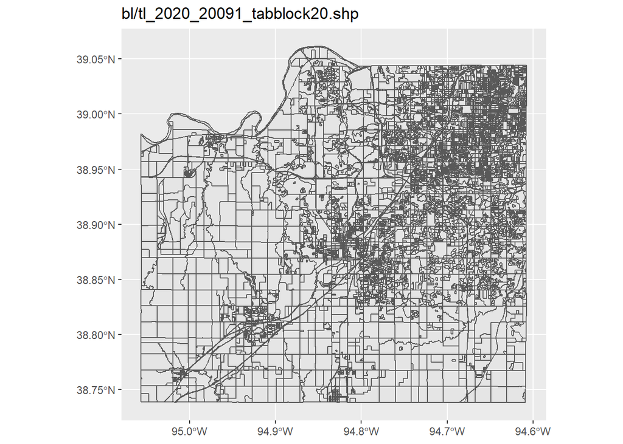

```r
s20091                                 %>%
   ggplot()                             +
      geom_sf(aes())                    +
      ggtitle(file_name)
```

### Leavenworth County, KS (20103)

```r
file_name <- "bl/tl_2020_20103_tabblock20.shp"
path_name                              %>%
  paste(file_name, sep="/")            %>%
  st_read(stringsAsFactors=FALSE)       -> s20103
glimpse(s20103)
```

```
## Rows: 2,203
## Columns: 16
## $ STATEFP20  <chr> "20", "20", "20", "20", "20", "20", "20", "20", "20", "20",~
## $ COUNTYFP20 <chr> "103", "103", "103", "103", "103", "103", "103", "103", "10~
## $ TRACTCE20  <chr> "070900", "071000", "071000", "071000", "070900", "071204",~
## $ BLOCKCE20  <chr> "2086", "1000", "2005", "2008", "2084", "1022", "1072", "10~
## $ GEOID20    <chr> "201030709002086", "201030710001000", "201030710002005", "2~
## $ NAME20     <chr> "Block 2086", "Block 1000", "Block 2005", "Block 2008", "Bl~
## $ MTFCC20    <chr> "G5040", "G5040", "G5040", "G5040", "G5040", "G5040", "G504~
## $ UR20       <chr> NA, NA, NA, NA, NA, NA, NA, NA, NA, NA, NA, NA, NA, NA, NA,~
## $ UACE20     <chr> NA, NA, NA, NA, NA, NA, NA, NA, NA, NA, NA, NA, NA, NA, NA,~
## $ UATYPE20   <chr> NA, NA, NA, NA, NA, NA, NA, NA, NA, NA, NA, NA, NA, NA, NA,~
## $ FUNCSTAT20 <chr> "S", "S", "S", "S", "S", "S", "S", "S", "S", "S", "S", "S",~
## $ ALAND20    <dbl> 642861, 626970, 12236, 0, 706391, 26879, 1382411, 130524, 3~
## $ AWATER20   <dbl> 0, 0, 0, 49190, 0, 0, 0, 0, 53946, 0, 0, 0, 0, 0, 0, 0, 0, ~
## $ INTPTLAT20 <chr> "+39.3208817", "+39.3135884", "+39.3170633", "+39.3154784",~
## $ INTPTLON20 <chr> "-095.0628834", "-095.0631022", "-095.0194171", "-095.03654~
## $ geometry   <POLYGON [°]> POLYGON ((-95.06751 39.3185..., POLYGON ((-95.06754~
```

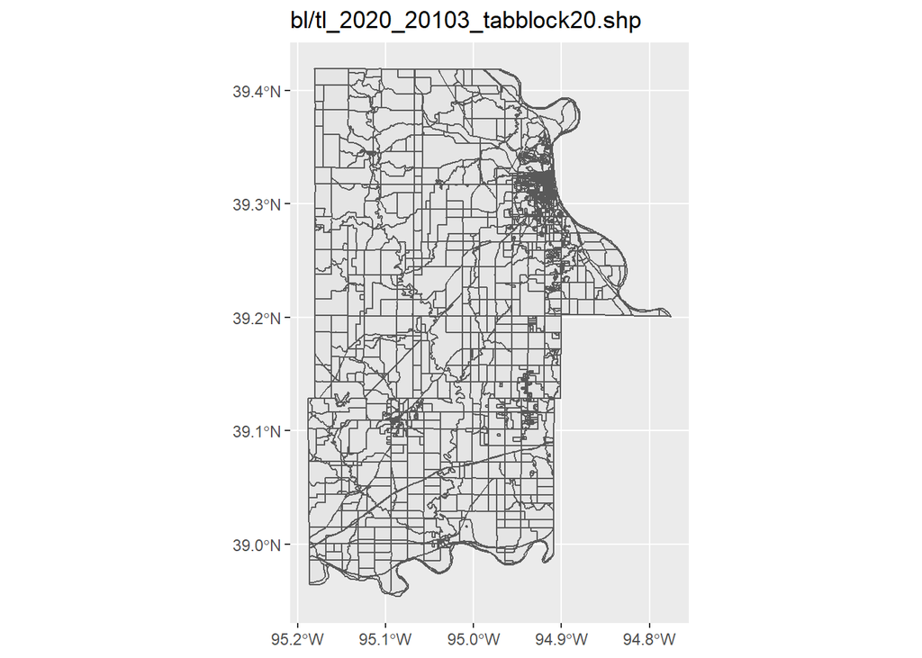

```r
s20103                                 %>%
   ggplot()                             +
      geom_sf(aes())                    +
      ggtitle(file_name)
```

### Miami County, KS (20121)

Miami County was included in earlier programs, but it is not needed for any of the work envisioned in this project.

### Wyandotte County, KS (20209)

```r
file_name <- "bl/tl_2020_20209_tabblock20.shp"
path_name                              %>%
  paste(file_name, sep="/")            %>%
  st_read(stringsAsFactors=FALSE)       -> s20209
glimpse(s20209)
```

```
## Rows: 3,355
## Columns: 16
## $ STATEFP20  <chr> "20", "20", "20", "20", "20", "20", "20", "20", "20", "20",~
## $ COUNTYFP20 <chr> "209", "209", "209", "209", "209", "209", "209", "209", "20~
## $ TRACTCE20  <chr> "043600", "042800", "042300", "042400", "042400", "042600",~
## $ BLOCKCE20  <chr> "4014", "2013", "3005", "3012", "3011", "3037", "3032", "30~
## $ GEOID20    <chr> "202090436004014", "202090428002013", "202090423003005", "2~
## $ NAME20     <chr> "Block 4014", "Block 2013", "Block 3005", "Block 3012", "Bl~
## $ MTFCC20    <chr> "G5040", "G5040", "G5040", "G5040", "G5040", "G5040", "G504~
## $ UR20       <chr> NA, NA, NA, NA, NA, NA, NA, NA, NA, NA, NA, NA, NA, NA, NA,~
## $ UACE20     <chr> NA, NA, NA, NA, NA, NA, NA, NA, NA, NA, NA, NA, NA, NA, NA,~
## $ UATYPE20   <chr> NA, NA, NA, NA, NA, NA, NA, NA, NA, NA, NA, NA, NA, NA, NA,~
## $ FUNCSTAT20 <chr> "S", "S", "S", "S", "S", "S", "S", "S", "S", "S", "S", "S",~
## $ ALAND20    <dbl> 87700, 462207, 293975, 151467, 16003, 17947, 115438, 512870~
## $ AWATER20   <dbl> 0, 0, 0, 0, 0, 0, 0, 0, 0, 0, 0, 0, 0, 0, 0, 0, 0, 0, 0, 0,~
## $ INTPTLAT20 <chr> "+39.0472306", "+39.0682579", "+39.0970515", "+39.0951582",~
## $ INTPTLON20 <chr> "-094.6790227", "-094.6577893", "-094.6459178", "-094.62816~
## $ geometry   <POLYGON [°]> POLYGON ((-94.68028 39.0528..., POLYGON ((-94.66196~
```

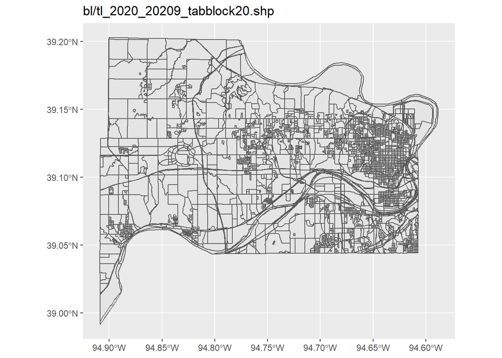

```r
s20209                                 %>%
   ggplot()                             +
      geom_sf(aes())                    +
      ggtitle(file_name)
```

### Cass County, MO (29037)

```r
file_name <- "bl/tl_2020_29037_tabblock20.shp"
path_name                              %>%
  paste(file_name, sep="/")            %>%
  st_read(stringsAsFactors=FALSE)       -> s29037
glimpse(s29037)
```

```
## Rows: 3,571
## Columns: 16
## $ STATEFP20  <chr> "29", "29", "29", "29", "29", "29", "29", "29", "29", "29",~
## $ COUNTYFP20 <chr> "037", "037", "037", "037", "037", "037", "037", "037", "03~
## $ TRACTCE20  <chr> "060307", "060904", "060904", "060904", "060800", "060800",~
## $ BLOCKCE20  <chr> "1009", "3021", "3024", "3034", "2072", "2068", "2088", "20~
## $ GEOID20    <chr> "290370603071009", "290370609043021", "290370609043024", "2~
## $ NAME20     <chr> "Block 1009", "Block 3021", "Block 3024", "Block 3034", "Bl~
## $ MTFCC20    <chr> "G5040", "G5040", "G5040", "G5040", "G5040", "G5040", "G504~
## $ UR20       <chr> NA, NA, NA, NA, NA, NA, NA, NA, NA, NA, NA, NA, NA, NA, NA,~
## $ UACE20     <chr> NA, NA, NA, NA, NA, NA, NA, NA, NA, NA, NA, NA, NA, NA, NA,~
## $ UATYPE20   <chr> NA, NA, NA, NA, NA, NA, NA, NA, NA, NA, NA, NA, NA, NA, NA,~
## $ FUNCSTAT20 <chr> "S", "S", "S", "S", "S", "S", "S", "S", "S", "S", "S", "S",~
## $ ALAND20    <dbl> 41672, 3813, 7346, 13553, 16075, 12832, 8606, 8623, 8707, 1~
## $ AWATER20   <dbl> 0, 0, 0, 0, 0, 0, 0, 0, 0, 0, 0, 0, 0, 0, 0, 0, 0, 0, 0, 0,~
## $ INTPTLAT20 <chr> "+38.8199142", "+38.6588677", "+38.6581899", "+38.6567624",~
## $ INTPTLON20 <chr> "-094.4585583", "-094.3481577", "-094.3481865", "-094.34437~
## $ geometry   <POLYGON [°]> POLYGON ((-94.46037 38.8201..., POLYGON ((-94.34856~
```

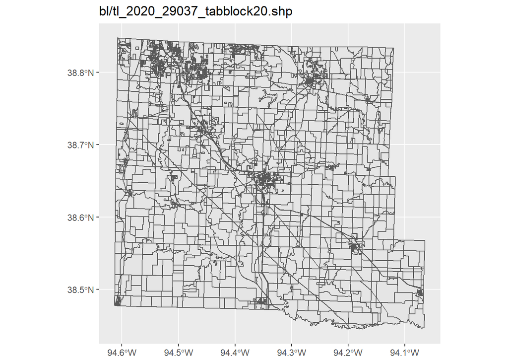

```r
s29037                                 %>%
   ggplot()                             +
      geom_sf(aes())                    +
      ggtitle(file_name)
```

### Clay County, MO (29047)

```r
file_name <- "bl/tl_2020_29047_tabblock20.shp"
path_name                              %>%
  paste(file_name, sep="/")            %>%
  st_read(stringsAsFactors=FALSE)       -> s29047
glimpse(s29047)
```

```
## Rows: 5,222
## Columns: 16
## $ STATEFP20  <chr> "29", "29", "29", "29", "29", "29", "29", "29", "29", "29",~
## $ COUNTYFP20 <chr> "047", "047", "047", "047", "047", "047", "047", "047", "04~
## $ TRACTCE20  <chr> "020603", "020902", "020603", "020603", "020603", "020603",~
## $ BLOCKCE20  <chr> "4019", "1022", "2018", "4011", "3000", "4014", "1021", "40~
## $ GEOID20    <chr> "290470206034019", "290470209021022", "290470206032018", "2~
## $ NAME20     <chr> "Block 4019", "Block 1022", "Block 2018", "Block 4011", "Bl~
## $ MTFCC20    <chr> "G5040", "G5040", "G5040", "G5040", "G5040", "G5040", "G504~
## $ UR20       <chr> NA, NA, NA, NA, NA, NA, NA, NA, NA, NA, NA, NA, NA, NA, NA,~
## $ UACE20     <chr> NA, NA, NA, NA, NA, NA, NA, NA, NA, NA, NA, NA, NA, NA, NA,~
## $ UATYPE20   <chr> NA, NA, NA, NA, NA, NA, NA, NA, NA, NA, NA, NA, NA, NA, NA,~
## $ FUNCSTAT20 <chr> "S", "S", "S", "S", "S", "S", "S", "S", "S", "S", "S", "S",~
## $ ALAND20    <dbl> 36972, 10466, 33287, 12642, 102691, 26335, 47484, 71959, 58~
## $ AWATER20   <dbl> 0, 0, 0, 0, 0, 0, 0, 0, 0, 0, 0, 0, 0, 0, 0, 0, 0, 0, 0, 0,~
## $ INTPTLAT20 <chr> "+39.1992955", "+39.2013722", "+39.1956950", "+39.1938706",~
## $ INTPTLON20 <chr> "-094.5039878", "-094.5068689", "-094.5053259", "-094.50966~
## $ geometry   <POLYGON [°]> POLYGON ((-94.50569 39.2004..., POLYGON ((-94.50722~
```

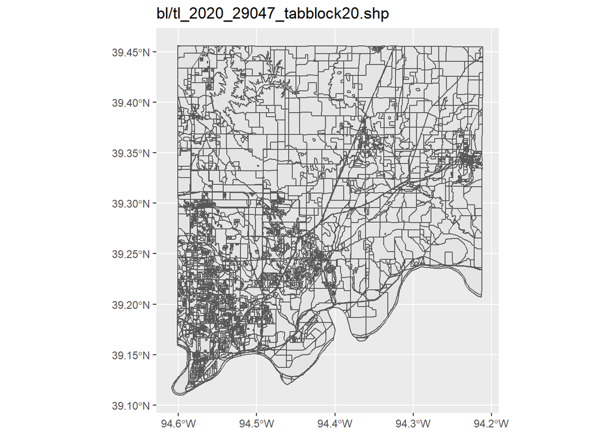

```r
s29047                                 %>%
   ggplot()                             +
      geom_sf(aes())                    +
      ggtitle(file_name)
```

### Jackson County, MO (29095)

```r
file_name <- "bl/tl_2020_29095_tabblock20.shp"
path_name                              %>%
  paste(file_name, sep="/")            %>%
  st_read(stringsAsFactors=FALSE)       -> s29095
glimpse(s29095)
```

```
## Rows: 14,842
## Columns: 16
## $ STATEFP20  <chr> "29", "29", "29", "29", "29", "29", "29", "29", "29", "29",~
## $ COUNTYFP20 <chr> "095", "095", "095", "095", "095", "095", "095", "095", "09~
## $ TRACTCE20  <chr> "002300", "000600", "015500", "015500", "014009", "017100",~
## $ BLOCKCE20  <chr> "2014", "1006", "1101", "1059", "2003", "4012", "1012", "10~
## $ GEOID20    <chr> "290950023002014", "290950006001006", "290950155001101", "2~
## $ NAME20     <chr> "Block 2014", "Block 1006", "Block 1101", "Block 1059", "Bl~
## $ MTFCC20    <chr> "G5040", "G5040", "G5040", "G5040", "G5040", "G5040", "G504~
## $ UR20       <chr> NA, NA, NA, NA, NA, NA, NA, NA, NA, NA, NA, NA, NA, NA, NA,~
## $ UACE20     <chr> NA, NA, NA, NA, NA, NA, NA, NA, NA, NA, NA, NA, NA, NA, NA,~
## $ UATYPE20   <chr> NA, NA, NA, NA, NA, NA, NA, NA, NA, NA, NA, NA, NA, NA, NA,~
## $ FUNCSTAT20 <chr> "S", "S", "S", "S", "S", "S", "S", "S", "S", "S", "S", "S",~
## $ ALAND20    <dbl> 14996, 21851, 73301, 7033, 18652, 42693, 70671, 114884, 741~
## $ AWATER20   <dbl> 0, 0, 0, 0, 0, 0, 0, 0, 0, 0, 0, 0, 0, 0, 0, 0, 0, 0, 0, 0,~
## $ INTPTLAT20 <chr> "+39.0894021", "+39.1148641", "+39.1127923", "+39.1199473",~
## $ INTPTLON20 <chr> "-094.5318307", "-094.5097976", "-094.5003033", "-094.49089~
## $ geometry   <POLYGON [°]> POLYGON ((-94.53234 39.0901..., POLYGON ((-94.51037~
```

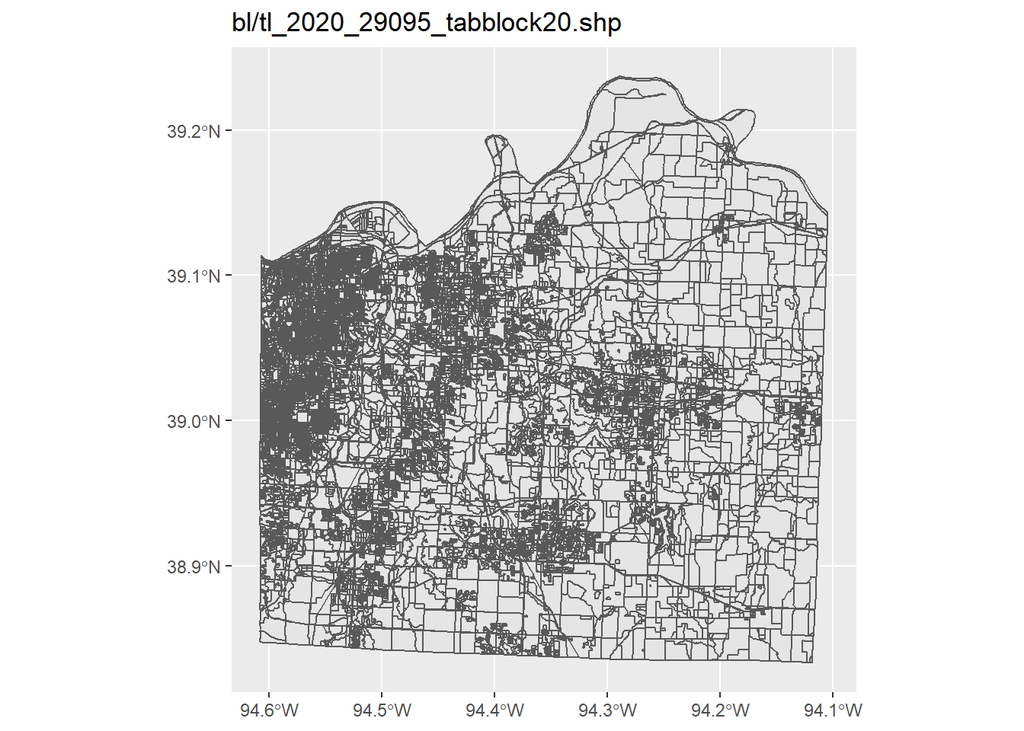

```r
s29095                                 %>%
   ggplot()                             +
      geom_sf(aes())                    +
      ggtitle(file_name)
```

### Platte County, MO (29165)

```r
file_name <- "bl/tl_2020_29165_tabblock20.shp"
path_name                              %>%
  paste(file_name, sep="/")            %>%
  st_read(stringsAsFactors=FALSE)       -> s29165
glimpse(s29165)
```

```
## Rows: 2,475
## Columns: 16
## $ STATEFP20  <chr> "29", "29", "29", "29", "29", "29", "29", "29", "29", "29",~
## $ COUNTYFP20 <chr> "165", "165", "165", "165", "165", "165", "165", "165", "16~
## $ TRACTCE20  <chr> "030215", "980000", "030207", "030216", "980000", "980000",~
## $ BLOCKCE20  <chr> "1007", "1119", "4009", "1034", "1123", "1099", "4016", "40~
## $ GEOID20    <chr> "291650302151007", "291659800001119", "291650302074009", "2~
## $ NAME20     <chr> "Block 1007", "Block 1119", "Block 4009", "Block 1034", "Bl~
## $ MTFCC20    <chr> "G5040", "G5040", "G5040", "G5040", "G5040", "G5040", "G504~
## $ UR20       <chr> NA, NA, NA, NA, NA, NA, NA, NA, NA, NA, NA, NA, NA, NA, NA,~
## $ UACE20     <chr> NA, NA, NA, NA, NA, NA, NA, NA, NA, NA, NA, NA, NA, NA, NA,~
## $ UATYPE20   <chr> NA, NA, NA, NA, NA, NA, NA, NA, NA, NA, NA, NA, NA, NA, NA,~
## $ FUNCSTAT20 <chr> "S", "S", "S", "S", "S", "S", "S", "S", "S", "S", "S", "S",~
## $ ALAND20    <dbl> 12222, 757161, 17513, 43838, 14295, 2016, 851880, 388735, 6~
## $ AWATER20   <dbl> 0, 0, 0, 0, 0, 0, 0, 0, 0, 0, 0, 0, 0, 0, 0, 0, 0, 0, 0, 0,~
## $ INTPTLAT20 <chr> "+39.2232228", "+39.2740529", "+39.2315517", "+39.2282460",~
## $ INTPTLON20 <chr> "-094.6650347", "-094.7175617", "-094.6529736", "-094.66196~
## $ geometry   <POLYGON [°]> POLYGON ((-94.66562 39.2233..., POLYGON ((-94.72255~
```

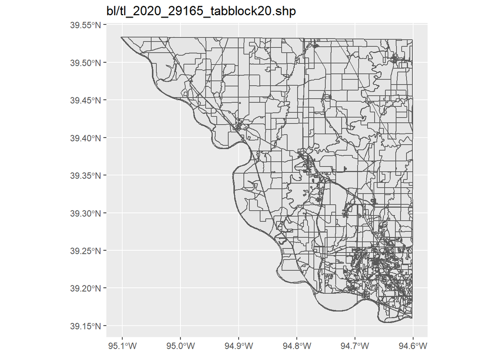

```r
s29165                                 %>%
   ggplot()                             +
      geom_sf(aes())                    +
      ggtitle(file_name)
```

### Combine files

```r
s20091                                 %>%
  bind_rows(s20103)                    %>%
  bind_rows(s20209)                    %>%
  bind_rows(s29037)                    %>%
  bind_rows(s29047)                    %>%
  bind_rows(s29095)                    %>%
  bind_rows(s29165)                     -> bl
```

### Rename variables

```r
bl                                     %>%
  mutate(bl_id=substr(GEOID20, 1, 15)) %>%
  rename(bl_name=NAME20)               %>%
  mutate(
    bl_area=
      as.numeric(st_area(bl)))         %>%
  mutate(bg_id=str_sub(bl_id, 1, 12))  %>%
  mutate(tr_id=str_sub(bl_id, 1, 11))  %>%
  select(
    bl_id,
    bl_name,
    bl_area,
    bg_id,
    tr_id,
    geometry)                           -> bl
glimpse(bl)
```

```
## Rows: 39,903
## Columns: 6
## $ bl_id    <chr> "200910518012010", "200910514003006", "200910515002005", "200~
## $ bl_name  <chr> "Block 2010", "Block 3006", "Block 2005", "Block 1009", "Bloc~
## $ bl_area  <dbl> 38500.823, 51711.677, 104537.047, 73933.762, 95854.528, 19934~
## $ bg_id    <chr> "200910518012", "200910514003", "200910515002", "200919800031~
## $ tr_id    <chr> "20091051801", "20091051400", "20091051500", "20091980003", "~
## $ geometry <POLYGON [°]> POLYGON ((-94.64213 38.9774..., POLYGON ((-94.63966 3~
```

### Store as an RData file

Placing the file in an RData format will speed up future use of this file.

```r
save(bl, file="../data/bl.RData")
```

An alternate set of shape files appear under the names

- TIGER2020/TABBLOCK/tl_2020_xx_tabblock10.zip

These are files from the 2010 Census.